# Cuantificación del mimetismo vocal heteroespecífico mediante aprendizaje profundo: evidencia en el pájaro campana

**Marcelo Araya-Salas**Universidad de Costa RicaPablo Huertas-VásquezUniversidad Nacional de Costa RicaMarcos Q. OlivaRoyal Holloway University of London

[figure not shown]

[figure not shown]

[figure not shown]

https://marce10.github.io/

## Evolución del aprendizaje vocal

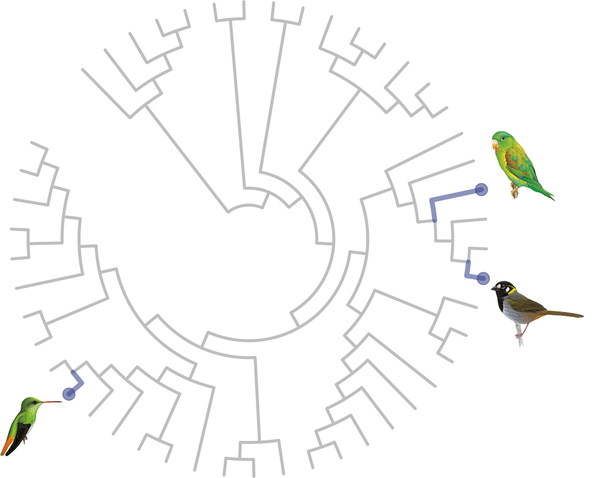

Jarvis 2004; Suh et al. 2011; filogenia: Open Tree of Life v1.7 (McTavish et al. 2025)

## Evolución del aprendizaje vocal

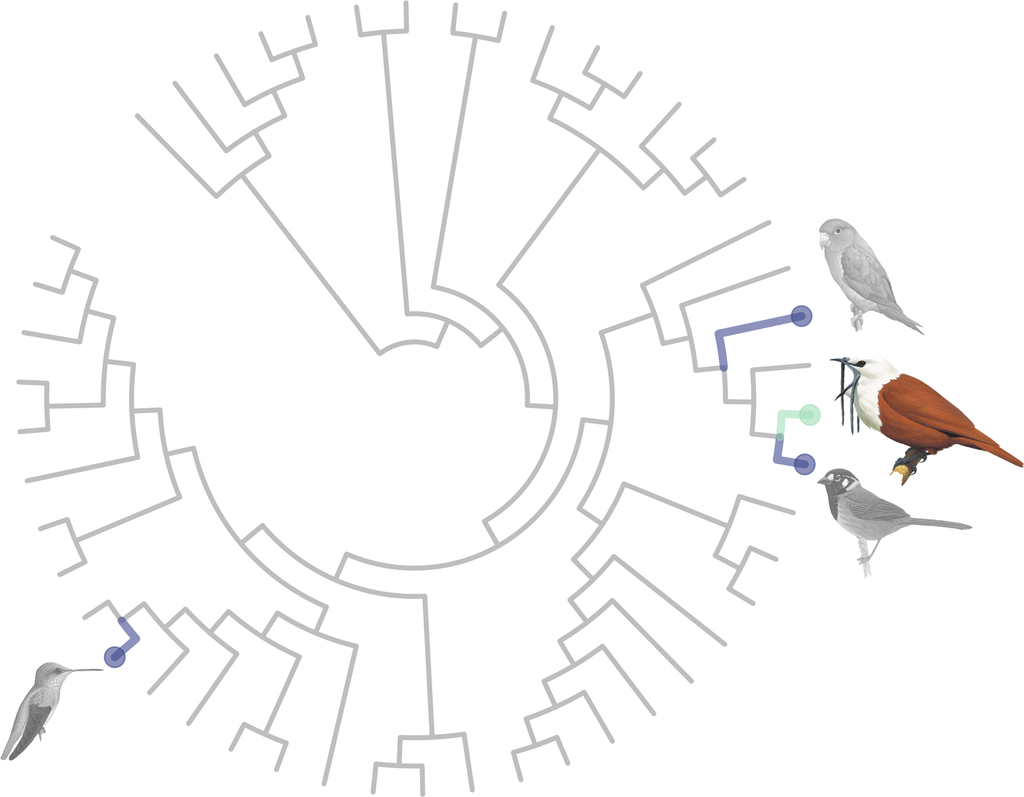

Jarvis 2004; Suh et al. 2011; filogenia: Open Tree of Life v1.7 (McTavish et al. 2025)

## Entrenamiento de los modelos

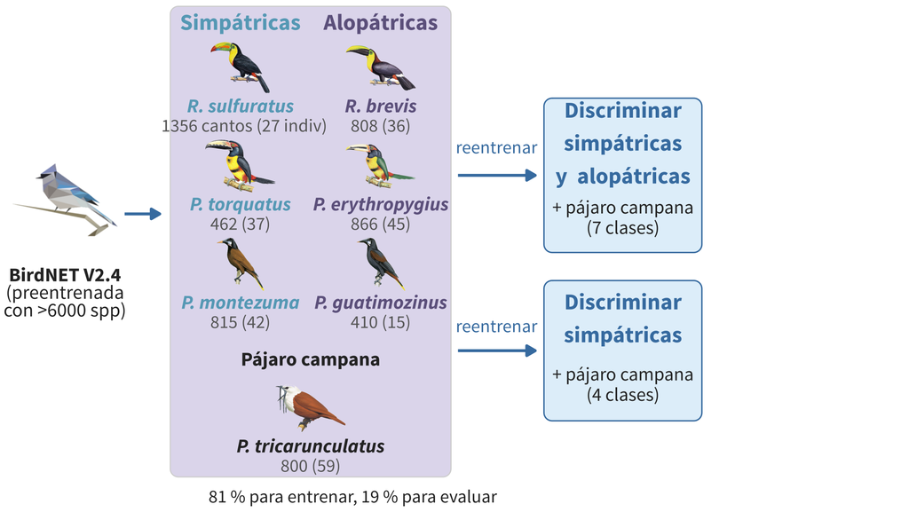

## Referencias

1. BirdLife International y Handbook of the Birds of the World (2025). Bird species distribution maps of the world. Versión 2025.2. [link](http://datazone.birdlife.org/species/requestdis)
2. Dalziell, A. H., Welbergen, J. A., Igic, B. y Magrath, R. D. (2015). Avian vocal mimicry: a unified conceptual framework. *Biological Reviews* 90: 643–668. [link](https://doi.org/10.1111/brv.12129)
3. Goller, M. y Shizuka, D. (2018). Evolutionary origins of vocal mimicry in songbirds. *Evolution Letters* 2: 417–426. [link](https://doi.org/10.1002/evl3.62)
4. Janik, V. M. y Slater, P. J. B. (2000). The different roles of social learning in vocal communication. *Animal Behaviour* 60: 1–11. [link](https://doi.org/10.1006/anbe.2000.1410)
5. Jarvis, E. D. (2004). Learned birdsong and the neurobiology of human language. *Annals of the New York Academy of Sciences* 1016: 749–777. [link](https://doi.org/10.1196/annals.1298.038)
6. Kahl, S., Wood, C. y Klinck, H. (2025). BirdNET Model V2.4. Zenodo. [link](https://doi.org/10.5281/ZENODO.15050749)
7. Kelley, L. A., Coe, R. L., Madden, J. R. y Healy, S. D. (2008). Vocal mimicry in songbirds. *Animal Behaviour* 76: 521–528. [link](https://doi.org/10.1016/j.anbehav.2008.04.012)
8. Kroodsma, D. E. et al. (2013). Behavioral evidence for song learning in the suboscine bellbirds (*Procnias* spp.; Cotingidae). *The Wilson Journal of Ornithology* 125: 1–14. [link](https://doi.org/10.1676/12-033.1)
9. McTavish, E. J. et al. (2025). A complete and dynamic tree of birds. *Proceedings of the National Academy of Sciences*.
10. Saranathan, V., Hamilton, D., Powell, G. V. N., Kroodsma, D. E. y Prum, R. O. (2007). Genetic evidence supports song learning in the three-wattled bellbird *Procnias tricarunculata*. *Molecular Ecology* 16: 3689–3702. [link](https://doi.org/10.1111/j.1365-294X.2007.03415.x)
11. Snow, B. K. (1970). A field study of the bearded bellbird in Trinidad. *Ibis* 112: 299–329. [link](https://doi.org/10.1111/j.1474-919X.1970.tb00109.x)
12. Snow, B. K. (1977). Territorial behavior and courtship of the male three-wattled bellbird. *The Auk* 94: 623–645. [link](https://doi.org/10.2307/4085260)
13. Suh, A. et al. (2011). Mesozoic retroposons reveal parrots as the closest living relatives of passerine birds. *Nature Communications* 2: 443. [link](https://doi.org/10.1038/ncomms1448)
14. Ten Cate, C. (2021). Re-evaluating vocal production learning in non-oscine birds. *Philosophical Transactions of the Royal Society B* 376: 20200249. [link](https://doi.org/10.1098/rstb.2020.0249)

← Volver a recursos

## Agradecimientos y recursos

**Financiamiento**: Centro de Investigación en Neurociencias, UCR

**Ilustraciones de aves**: Birds of the World (Cornell Lab of Ornithology)

**Fotos**: David Jimenez

**Sitio del proyecto**: análisis, código y esta presentación  
[marce10.github.io/bellbird_vocal_mimicry](https://marce10.github.io/bellbird_vocal_mimicry/)

**Repositorio en GitHub**  
github.com/maRce10/bellbird_vocal_mimicry

[figure not shown]

**suwo**: grabaciones de repositorios en línea desde R  
[docs.ropensci.org/suwo](https://docs.ropensci.org/suwo/)

[figure not shown]

**BirdNET**: identificación de aves por sonido con aprendizaje profundo  
[birdnet.cornell.edu](https://birdnet.cornell.edu/)

[figure not shown]

**dynaSpec**: los espectrogramas con sonido de esta presentación  
[marce10.github.io/dynaSpec](https://marce10.github.io/dynaSpec/)

Referencias citadas

[figure not shown]

Esta presentación